# Milestone Report

### Executive Summary

The aim of this project is to develop a text prediction system similar to that found on mobile phones. The system will be trained on data provided by HelioHost.org.

Text from these files will be processed, cleaned, summarized and developed into an algorithm that will be incorporated into a publicly available website hosted by shinyapps.io.

### Data Overview

The raw data consists of 3 files that include text from different sources:  
* News  
* Blogs  
* Twitter

Each file includes numerous documents, each of which can represent a short phrase or many paragraphs. In addition, the number of documents in each file is not uniform: The twitter file includes the largest number of documents, more than both the blogs and news files combined.

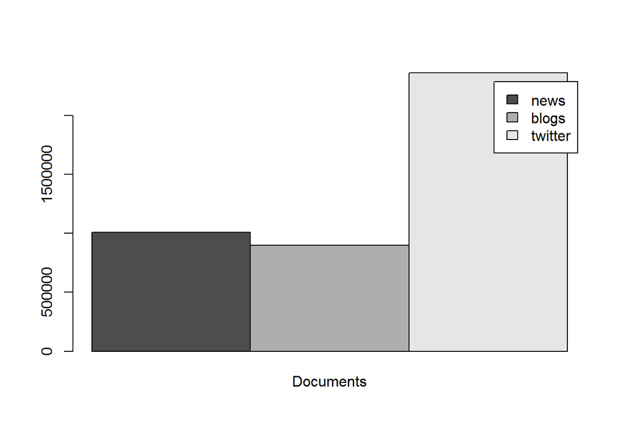

```
##         Documents
## news      1010242
## blogs      899288
## twitter   2360148
```

However, as expected, each twitter document is constrained by the 140 character limit. So while the twitter document contributes the largest number of documents, the total amount of text coming from each tweet is far smaller.

Below is a set of boxplots showing word counts per document for each file. The y-axis has been standardized. However, because of the large impact of outliers on the “Blog” chart, I have truncated the y-axis at just above the 3rd quartile.

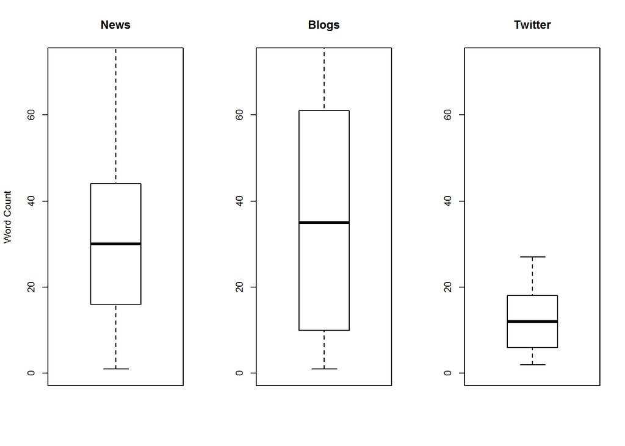

Allowing the y-axis to self-adjust shows the large number of outliers in the blog file.

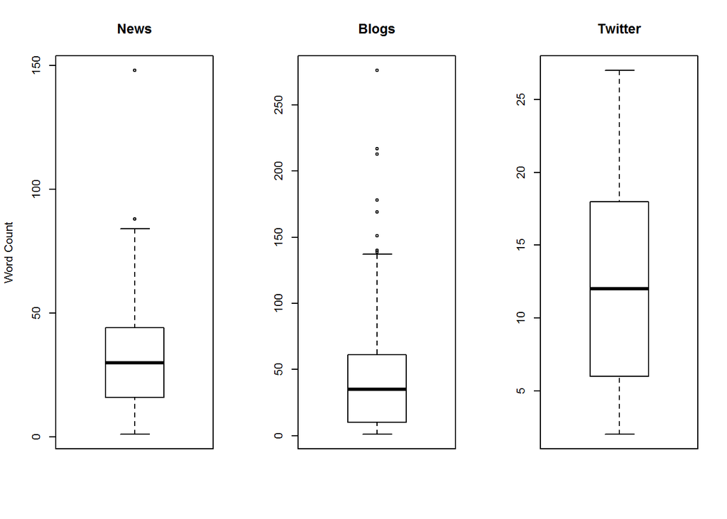

Below is a set of histograms showing the percentage that each word count (x-axis) represents in the particular text file. Twitter documents have significantly lower values while blogs tend to have many more long form articles than do new documents. A majority of documents from the News file stay at the 50 word or less range.

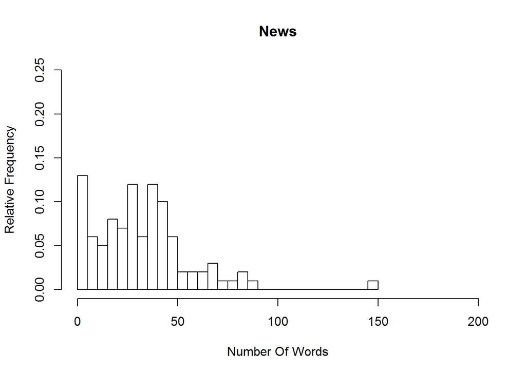

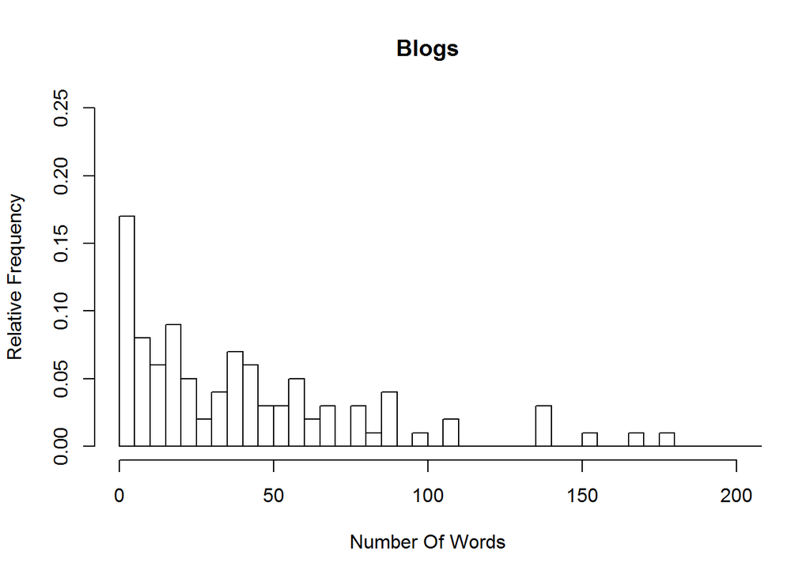

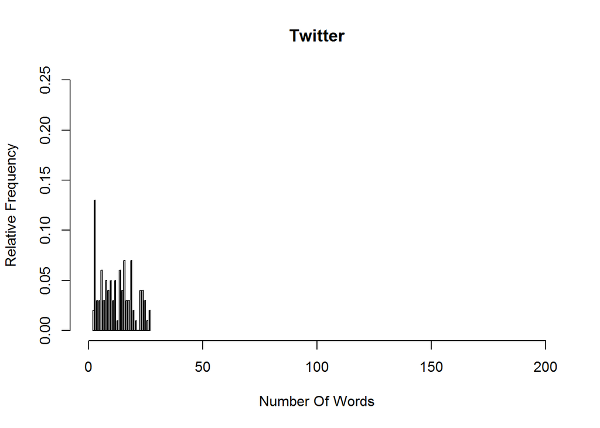

```
##         Documents Unique Words Total Words Average Words
## news          100       236837    33950341   0.006975983
## blogs         100       294639    37137935   0.007933640
## twitter       100       323741    29709877   0.010896747
```

### N-gram Approach For Text Prediction

Text prediction will be accomplished by calculating and storing frequency counts of n-grams, using 1, 2, 3 and 4 word combinations. Prediction will based on finding matches with the longer n-grams and when no matches are found (or multiple matches with similar probability exist) the algorithm will “backoff” and incorporate information from smaller n-grams to improve accuracy.

The amount of data that this includes is daunting so the underlying data used by the algorithm will need to be minimized and optimized. 4-grams alone represent over 2 GB of data, so filtering out n-grams that are not useful or contribute little value is imperative.

As an initial step for data reduction, I combined each set of n-grams from each file together. From there, I removed “singletons”, any n-gram that only appeared once in any of the three files. (i.e. - Appeared in “News”" but not in “Blogs” or “Twitter.”“)

Below is a summary of the initial set of n-grams vs one where singletons were removed. There are just over 600K unigrams in the combined text but they lead to almost 70 million 4-grams. Removing singletons reduces this massive quantity down to under 6 million 4-grams.

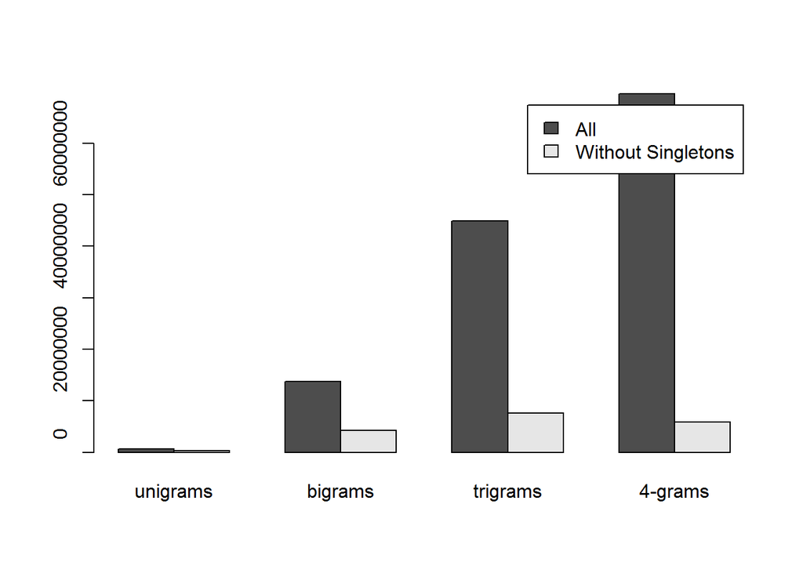

From removing words/phrases that only occur once to words that are frequently represented, below are the top 50 words found in the text data. This list DOES exclude stopwords like “the”.

```
##   will   said   just    one   like     im    can    get   time    new
## 315794 305242 305156 298843 273597 249303 247036 227385 224805 195472
##    now   good   dont    day   know   love people   back     go  first
## 180925 180782 177014 176068 163917 161723 159269 145279 142264 141120
##   year    see   well   make   also  going  think   last  great    two
## 139962 139464 132845 131515 130502 127048 126578 125714 124710 123516
##   much     us really    way  today      u   even    got   want   work
## 120930 119663 114552 113233 111237 110234 108537 108519 107547 106820
##  right  still  years thanks   need   life  thats     rt   many   cant
## 104729 103019 101266  99077  97892  91680  90480  89894  89220  87193
```